# Homework 9

*Enter your name and EID here*

Connor Hanna cdh3663

**This homework is due on April 18, 2022 at 11:00pm. Please submit as a pdf file on Canvas.**

For all problems in this homework, we will work with the `heart_disease_data` dataset, which is a simplified and recoded version of a dataset available from kaggle. You can read about the original dataset here: https://www.kaggle.com/datasets/kamilpytlak/personal-key-indicators-of-heart-disease?resource=download

The `heart_disease_data` dataset contains 9 variables: `HeartDisease`(whether or not the participant has heart disease), `BMI` (body mass index), `PhysicalHealth` (how many days a month was their physical health not good), `MentalHealth` (how many days a month was their mental health not good), `ApproximateAge` (participants age), `SleepTime` (how many hours of sleep do they get in a 24-hour period), `Smoking` (1-smoker, 0-nonsmoker), `AlcoholDrinking` (1-drinks alcohol, 0-does not drink), `PhysicalActivity` (1-did physical activity or exercise during the past 30 days, 0-hardly any physical activity). Compared to the original dataset, the columns `ApproximateAge`, `Smoking`, `AlcoholDrinking`, and `PhysicalActivity` have been converted into numeric columns so they can be included in a PCA.

**Note:** This homework is about the contents of the plots. Don’t worry about styling. It’s OK to use the default theme and plot labeling.

```r
heart_data <- read_csv("https://wilkelab.org/SDS375/datasets/heart_disease_data.csv")
```

**Problem 1: (5 pts)**

Perform a PCA of the `heart_disease_data` dataset and make two plots: 1. A rotation plot of components 1 and 2; 2. A plot of the eigenvalues, showing the amount of variance explained by the various components.

```r
# performing PCA
pca_fit <-
  heart_data |>
    select(where(is.numeric)) |>
    scale() |>
    prcomp()

# adding pca components back into the dataframe
heart_data_pca <-
  pca_fit |>
    augment(heart_data)
```

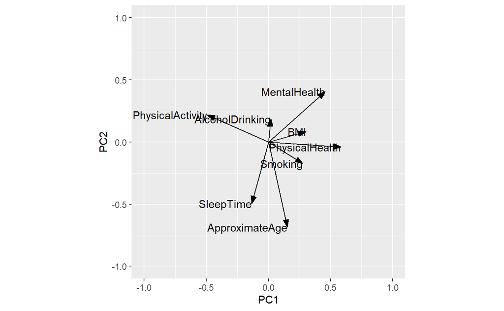

```r
# arrow style settings
arrow_style <-
  arrow(
    angle = 20, length = grid::unit(8, "pt"),
    ends = "first", type = "closed"
  )

# rotation plot of components 1 and 2
pca_fit |>
  tidy(matrix = "rotation") |>
  pivot_wider(
    names_from = "PC", values_from = "value",
    names_prefix = "PC"
  ) |>
  ggplot(aes(PC1, PC2)) +
  geom_segment(
    xend = 0, yend = 0,
    arrow = arrow_style
  ) +
  geom_text(aes(label = column), hjust = 1) +
  xlim(-1, 1) + ylim(-1, 1) +
  coord_fixed()
```

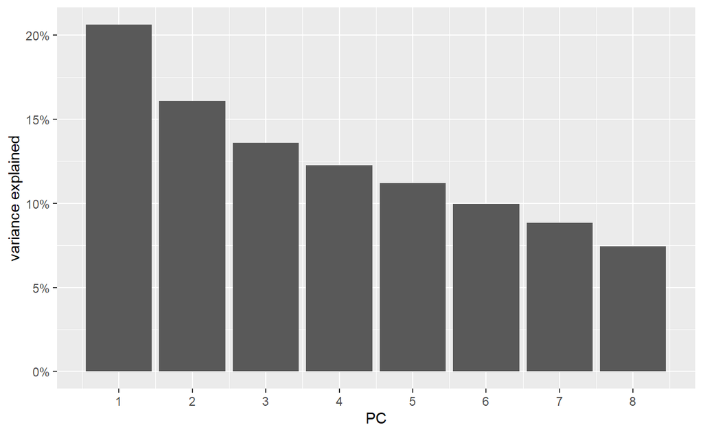

```r
# eigenvalue plot

pca_fit |>
  tidy(matrix = "eigenvalues") |>
  ggplot(aes(PC, percent)) +
  geom_col() +
  scale_x_continuous(
    breaks = 1:8
  ) +
  scale_y_continuous(
    name = "variance explained",
    label = scales::label_percent(accuracy = 1)
  )
```

**Problem 2: (5 pts)** Make a scatter plot of PC 2 versus PC 1 and color by heart disease status. Then use the rotation plot from Problem 1 to describe the variables/factors by which we can separate the study participants with heart disease from the study participants without heart disease.

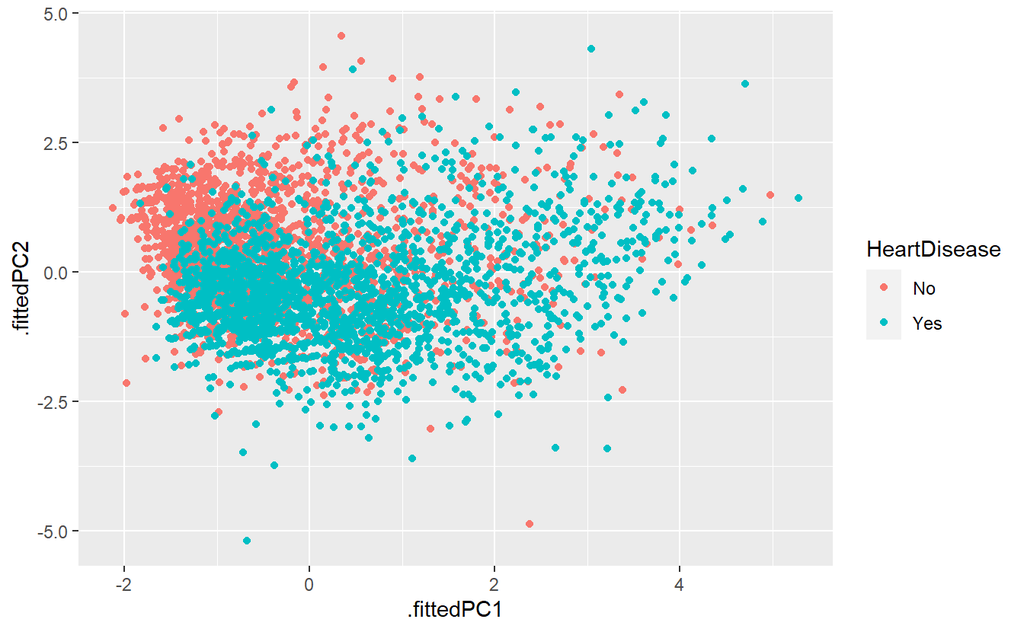

```r
heart_data_pca |>
  ggplot(
    aes(.fittedPC1, .fittedPC2)
  ) +
  geom_point(aes(color = HeartDisease))
```